# Bioinformatics of high throughput analyses - Homework1

Group 7: Nynne Nymann, Peter Horskjr, Carlotta Porcelli, Max Tomlinson & Ke Zhai

5/5/2017

```r
# clearing R-history and reading data
rm(list=ls())
gene_lengths<-read.table("gene_lengths_v2.txt", header=T)
```

# Question 1 - typical number of exon

## Make a histogram that shows what the typical number of exons is. Adjust the bins so that we can pinpoint exactly what number of exons that is the most common. Comment the plot.

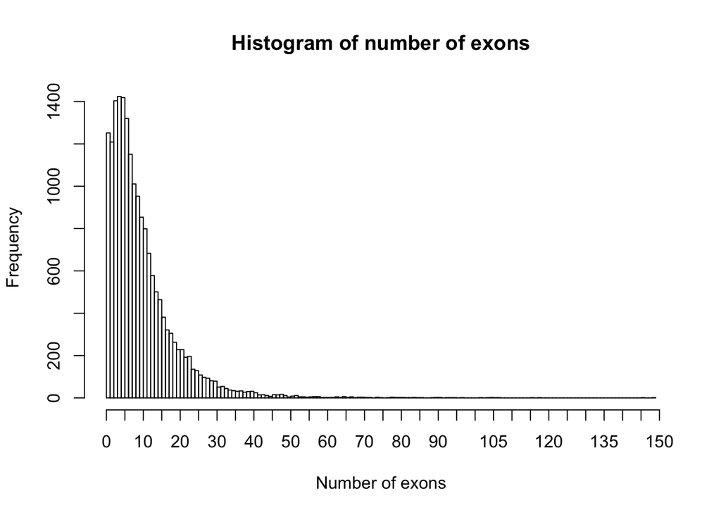

```r
hist(gene_lengths$exon_count, breaks=seq(0,max(gene_lengths$exon_count),by=1), xaxt="n",
     main="Histogram of number of exons", xlab="Number of exons")
axis(side=1, at=seq(0,150,5), labels=T)
```

The histogram shows the distribution of exon count. The common number of exons lies between 3 to 5 with the most typical number of exons being equal to 4 (narrow margin). The number of genes consisting of higher number of exons decreases drastic after exon count number 5.

# Question 2

## Add additional column to the dataframe that contains the total length of introns for each gene

The length of an intron is the difference between the length of the gene and its mRNA. Hence:

```r
gene_lengths$intron_length<-gene_lengths$genome_length-gene_lengths$mrna_length
```

# Question 3

## Make histograms and boxplots showing the distribution of total exon and total intron lengths, all as subplots in the same larger plot, where each dataset have a different color. On the histograms, the number of bins should be exactly the same, and the x-axis should have the same scale. Comment the plot – are exons larger than introns or vice versa?

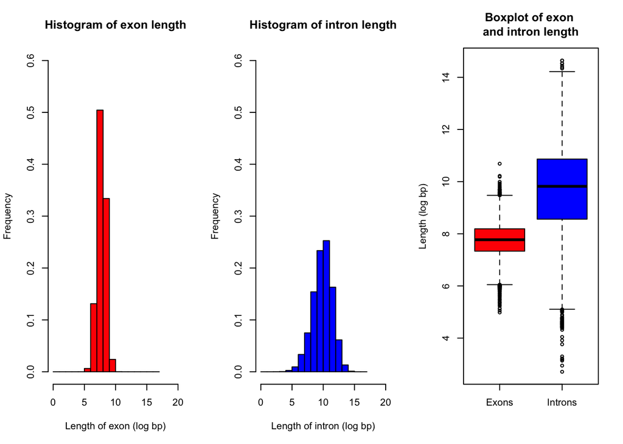

```r
par(mfrow=c(1,3))

#Exon_length histogram:
hist(log(gene_lengths$mrna_length),col="red",xlim=c(0,20),breaks=seq(0,17),
ylim=c(0,0.6), freq = F,main="Histogram of exon length", ylab="Frequency", xlab="Length of exon (log bp)")

#Intron_length histogram:
hist(log(gene_lengths$intron_length),col="blue",xlim=c(0,20),breaks=seq(0,17),
ylim=c(0,0.6),freq = F, main="Histogram of intron length", ylab="Frequency", xlab="Length of intron (log bp)")

#Boxplot for exon and intron length:
boxplot(log(gene_lengths$mrna_length),log(gene_lengths$intron_length),
col=c("red","blue"),names=c("Exons","Introns"),main="Boxplot of exon
and intron length",ylab="Length (log bp)")
```

A log-transformation has been done in order to avoid deformed plots and to get a better visualization of the data. By analyzing both the histograms and the boxplot, it is evident that the length of introns is longer than that of exons. In addition, the variance of introns is larger when comparing to that of exons

# Question 4

## Are the mRNA lengths significantly longer than the total intron lengths, or is it the other way around?

To answer this particular question the performance of a statistic test is needed. The choice of test depends on the ability to satisfy the given assumptions. To help us out, we used the qqnorm function in R to determine whether our data was normal distributed or not. As shown below, both the length of exons and introns doesn’t follow a normal distribution and we are obliged to use a non-parametric test. Since we have two distributions to compare, a wilcoxon test is the most appropriate to use.

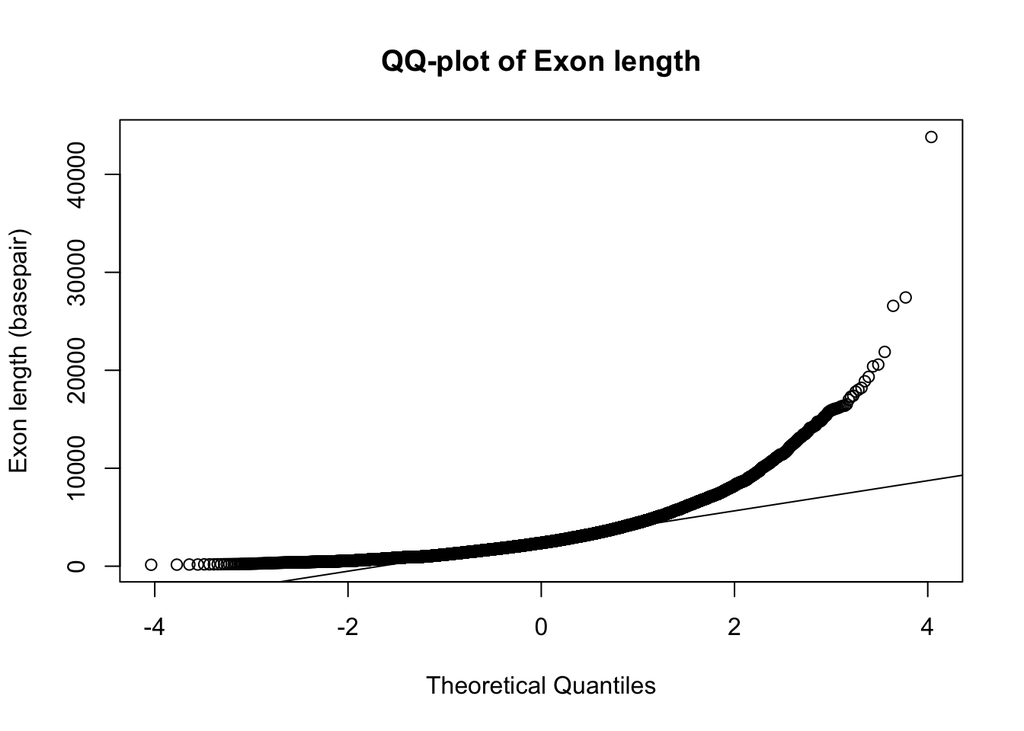

```r
#QQ_plot for exon length
qqnorm(gene_lengths$mrna_length,ylab="Exon length (basepair)",main="QQ-plot of Exon length")
qqline(gene_lengths$mrna_length)
```

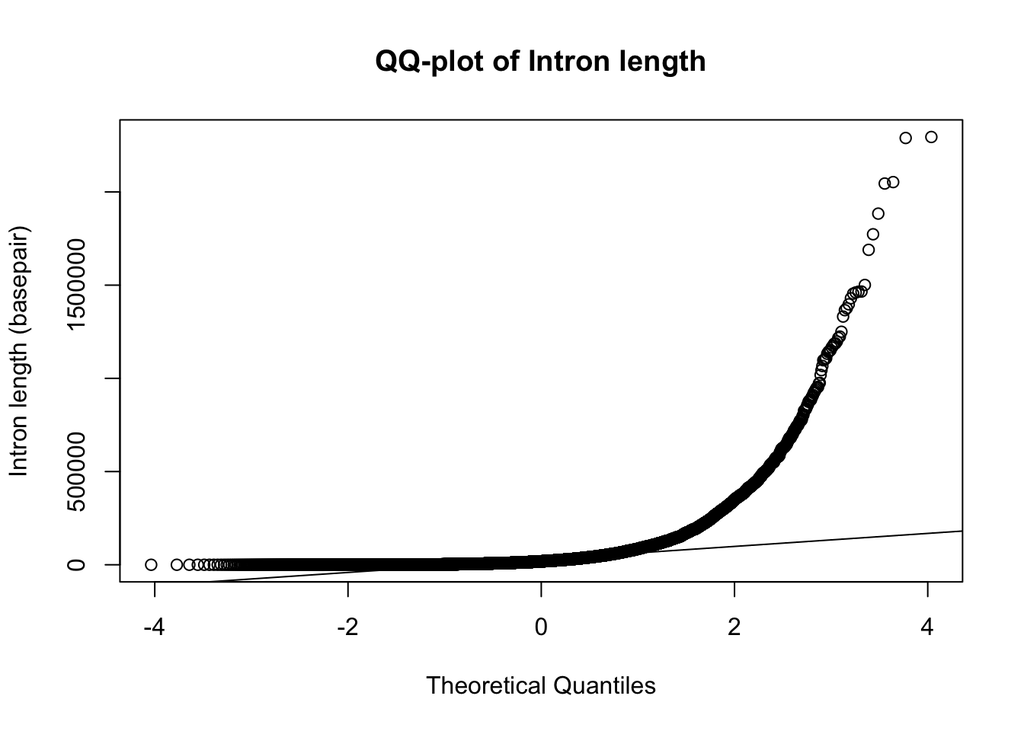

```r
#QQ_plot for intron length
qqnorm(gene_lengths$intron_length,ylab="Intron length (basepair)",main="QQ-plot of Intron length")
qqline(gene_lengths$intron_length)
```

The wilcoxon test does not look at the difference in medians but instead test the difference in U-statistics which is a measure of rank shifts. Measuring U statistics is an advantage since it takes all values into consideration as opposed to the median. Our hypotheses for the wilcoxon test are in this fashion:  
H0 = The U-statistic between the length of mRNAs and introns is the same  
HA= The U-statistic between the length of mRNAs and introns is not the same